# Исследования рынка общепита в Москве для принятия решения об открытии нового заведения

## Описание проекта

Есть идея открыть кафе в Москве. Кафе оригинальное — гостей должны обслуживать роботы. Проект многообещающий, но дорогой. Необходимо обратиться к инвесторам. Инвесторов интересует текущее положение дел на рынке — останется ли ресторан популярным на долгое время, когда все зеваки насмотрятся на роботов-официантов?

Имеются открытые данные о заведениях общественного питания в Москве.

**Необходимо подготовить исследование рынка и ответить на вопросы**:

1. Для какого вида объекта общественного питания характерно сетевое распространение?
2. Что характерно для сетевых заведений: много заведений с небольшим числом посадочных мест в каждом или мало заведений с большим количеством посадочных мест?
3. Какой вид предоставляет в среднем самое большое количество посадочных мест?
4. Какие закономерности можно выявить, посмотрев на распределение количества посадочных мест для улиц с большим количеством объектов общественного питания?

# Итоги

Определили самые популярные типы заведений. Выявили районы, в которых находится много точек питания, и районы, в которых точек питания мало. Сформировали рекомендации для инвесторов, подготовили презентацию. В ходе работы над проектом потребовалось получить район расположения кафе-конкурентов из внешних источников.

## Описание данных

**Таблица rest_data**:

- `id` — идентификатор объекта;
- `object_name` — название объекта общественного питания;
- `chain` — сетевой ресторан;
- `object_type` — тип объекта общественного питания;
- `address` — адрес;
- `number` — количество посадочных мест.

## Содержание проекта

1. Подготовка данных для анализа
2. Анализ данных
3. Презентация

```python
import pandas as pd
import matplotlib.pyplot as plt
import seaborn as sns
import plotly.express as px
from plotly import graph_objects as go
from plotly.subplots import make_subplots
import warnings
warnings.filterwarnings('ignore')

pd.options.display.max_colwidth = 150
sns.set_style('white')
```

# Подготовка данных для анализа

Необходимо изучить данные. Проверить:

- соответствие данных их типам
- написание названий полей
- написание текстовых полей-справочников (признак сети, тип объекта)
- наличие пропусков
- наличие дублей (полных/частичных)

```python
# получаем данные
rest_data = pd.read_csv('datasets/rest_data.csv')
rest_data.head()
```

|  | id | object_name | chain | object_type | address | number |
| --- | --- | --- | --- | --- | --- | --- |
| 0 | 151635 | СМЕТАНА | нет | кафе | город Москва, улица Егора Абакумова, дом 9 | 48 |
| 1 | 77874 | Родник | нет | кафе | город Москва, улица Талалихина, дом 2/1, корпус 1 | 35 |
| 2 | 24309 | Кафе «Академия» | нет | кафе | город Москва, Абельмановская улица, дом 6 | 95 |
| 3 | 21894 | ПИЦЦЕТОРИЯ | да | кафе | город Москва, Абрамцевская улица, дом 1 | 40 |
| 4 | 119365 | Кафе «Вишневая метель» | нет | кафе | город Москва, Абрамцевская улица, дом 9, корпус 1 | 50 |

```python
# получаем инфо по данным и проверяем пропуски
rest_data.info()
```

```
<class 'pandas.core.frame.DataFrame'>
RangeIndex: 15366 entries, 0 to 15365
Data columns (total 6 columns):
id             15366 non-null int64
object_name    15366 non-null object
chain          15366 non-null object
object_type    15366 non-null object
address        15366 non-null object
number         15366 non-null int64
dtypes: int64(2), object(4)
memory usage: 720.4+ KB
```

```python
rest_data.columns
```

```
Index(['id', 'object_name', 'chain', 'object_type', 'address', 'number'], dtype='object')
```

Типы соответстуют хранимой информации. Пропусков в данных нет. C наименованием полей все ок.

```python
# проверяем возможные значения текстовых полей
print(f'Флаг "Сетевой ресторан"')
display(rest_data['chain'].value_counts())

print(f'Поле "Тип объекта"')
display(rest_data['object_type'].value_counts())
```

```
Флаг "Сетевой ресторан"
```

```
нет    12398
да      2968
Name: chain, dtype: int64
```

```
Поле "Тип объекта"
```

```
кафе                                 6099
столовая                             2587
ресторан                             2285
предприятие быстрого обслуживания    1923
бар                                   856
буфет                                 585
кафетерий                             398
закусочная                            360
магазин (отдел кулинарии)             273
Name: object_type, dtype: int64
```

В написании справочных данных ошибок нет.

```python
# проверка на наличие полных дублей
rest_data.duplicated().sum()
```

```
0
```

Полных дублей в данных нет. При этом важно понимать, что рассматриваем строки целиком, а поле id формировалось автоматически — дублей быть и не может. Стоит рассмотреть дубли по сету: наименование, тип объекта, адрес. В сет включен тип объекта, так как теоретически на одном адресе может оказаться две точки одного заведения: ресторан и кофейня с булочками. Число посадочных мест не учитывем, так как оно, скорее всего, указано приблизительно.

```python
# проверка на наличие частичных дублей
(
    rest_data[rest_data.duplicated(subset = ['object_name','object_type', 'address'], keep=False)]
    .sort_values(by = ['object_name', 'address'])
)
```

|  | id | object_name | chain | object_type | address | number |
| --- | --- | --- | --- | --- | --- | --- |
| 8004 | 153873 | Eat and talk | нет | ресторан | город Москва, улица Воздвиженка, дом 4/7, строение 2 | 80 |
| 8005 | 154087 | Eat and talk | нет | ресторан | город Москва, улица Воздвиженка, дом 4/7, строение 2 | 10 |
| 6371 | 135225 | IL PATIO | нет | ресторан | город Москва, Манежная площадь, дом 1, строение 2 | 89 |
| 6372 | 135231 | IL PATIO | нет | ресторан | город Москва, Манежная площадь, дом 1, строение 2 | 45 |
| 2869 | 25031 | LALTRO BOSCO | нет | ресторан | город Москва, улица Петровка, дом 10 | 145 |
| ... | ... | ... | ... | ... | ... | ... |
| 15365 | 222535 | Шоколадница | да | кафе | город Москва, Ходынский бульвар, дом 4 | 10 |
| 15362 | 209264 | Шоколадница | да | кафе | город Москва, улица Земляной Вал, дом 33 | 10 |
| 15363 | 209186 | Шоколадница | да | кафе | город Москва, улица Земляной Вал, дом 33 | 20 |
| 14376 | 217108 | Шурма | нет | предприятие быстрого обслуживания | город Москва, Ярцевская улица, дом 25А | 0 |
| 14379 | 217555 | Шурма | нет | предприятие быстрого обслуживания | город Москва, Ярцевская улица, дом 25А | 0 |

286 rows × 6 columns

При детальном рассмотрении данных оказалось, что заведения одной сети могут иметь разные написания названий (например Burger King и Бургер Кинг). Обработать вручную каждое из исключений сложно. Для крупных известных сетей названия приведем к стандартным. Также приведем все названия к верхнему регистру.

```python
# создание столбца с наименованием заведения в нижнем регистре для удобства лемматизации английских слов
rest_data['corr_object_name'] = rest_data['object_name'].str.lower()

from pymystem3 import Mystem
m = Mystem()

import nltk
nltk.download('wordnet')
from nltk.stem import WordNetLemmatizer
lemmatizer = WordNetLemmatizer()

def corr_object_name(object_name):
    if 'бургер' in m.lemmatize(object_name) and 'кинг' in m.lemmatize(object_name):
        return 'БУРГЕР КИНГ'
    if 'burger' in lemmatizer.lemmatize(object_name) and 'king' in lemmatizer.lemmatize(object_name):
        return 'БУРГЕР КИНГ'
    if 'макдоналдс' in m.lemmatize(object_name):
        return 'МАКДОНАЛДС'
    if 'шоколадница' in m.lemmatize(object_name):
        return 'ШОКОЛАДНИЦА'
    if 'kfc' in lemmatizer.lemmatize(object_name):
        return 'KFC'
    if 'starbucks' in lemmatizer.lemmatize(object_name) or 'старбакс' in m.lemmatize(object_name) :
        return 'СТАРБАКС'
    if 'караваев' in m.lemmatize(object_name) and 'брат' in m.lemmatize(object_name):
        return 'БРАТЬЯ КАРАВАЕВЫ'
    if 'patio' in lemmatizer.lemmatize(object_name) or 'патио' in m.lemmatize(object_name):
        return 'ИЛЬ ПАТИО'
    if 'андерсон' in m.lemmatize(object_name):
        return 'АНДЕРСОН'
    if 'му' in m.lemmatize(object_name):
        return 'МУ-МУ'
    if 'теремок' in m.lemmatize(object_name):
        return 'ТЕРЕМОК'
    if 'якитория' in m.lemmatize(object_name):
        return 'ЯКИТОРИЯ'
    if 'данкин' in m.lemmatize(object_name) or 'dunkin' in lemmatizer.lemmatize(object_name):
        return 'ДАНКИН ДОНАТС'
    if 'сабвевать' in m.lemmatize(object_name) or 'сабвэй' in m.lemmatize(object_name) or 'subway' in lemmatizer.lemmatize(object_name):
        return 'SUBWAY'
    return object_name

rest_data['corr_object_name'] = rest_data['corr_object_name'].apply(corr_object_name)
```

```python
rest_data['corr_object_name'] = rest_data['corr_object_name'].str.upper()
```

```python
duplicates_amt = rest_data.duplicated(subset = ['corr_object_name','object_type', 'address']).sum()
print('Количество дубликатов до:', duplicates_amt)
print('Это {:.2%} от общего объема данных'.format(duplicates_amt/rest_data.shape[0]))
```

```
Количество дубликатов до: 197
Это 1.28% от общего объема данных
```

Возникли частичные дубли: 197 штук (1.28% от общего объема данных). Если бы их было значительное количество (более 10%), то можно было рассчитать среднее значение посадочных мест на каждый из объектов, так как в дублирующихся записях эта информация расходится. Но % дублей мал и тратить время на это не стоит. Просто удалим дубли

```python
rest_data = rest_data.drop_duplicates(subset = ['corr_object_name','object_type', 'address']).reset_index(drop = True)
print('Количество дубликатов после:', rest_data.duplicated(subset = ['corr_object_name','object_type', 'address']).sum())
```

```
Количество дубликатов после: 0
```

# Анализ данных

### Исследуем соотношение видов объектов общественного питания по количеству

```python
report = rest_data.groupby('object_type', as_index = False)['id'].count().sort_values(by='id', ascending = False)
report.columns = ['object_type', 'amount_total']
report['part'] = (report['amount_total']/report['amount_total'].sum())
report['part'] = report.apply(lambda x:'{:.2%}'.format(x['part']), axis = 1)
report
```

|  | object_type | amount_total | part |
| --- | --- | --- | --- |
| 3 | кафе | 6003 | 39.57% |
| 8 | столовая | 2575 | 16.98% |
| 7 | ресторан | 2268 | 14.95% |
| 6 | предприятие быстрого обслуживания | 1888 | 12.45% |
| 0 | бар | 853 | 5.62% |
| 1 | буфет | 570 | 3.76% |
| 4 | кафетерий | 393 | 2.59% |
| 2 | закусочная | 347 | 2.29% |
| 5 | магазин (отдел кулинарии) | 272 | 1.79% |

```python
report_plot = px.bar(report, x='object_type', y = 'amount_total',
                    title = 'Cоотношение типов объектов общественного питания ', text = 'part')

# форматируем график
report_plot.update_layout(template = 'plotly_white',
                          xaxis_title = 'Тип объекта',
                          yaxis_title = 'Количество объектов, шт.')
report_plot.update_traces(textposition = 'outside')

report_plot.show()
```

[interactive chart not shown]

```python
# для дальнейшего использования
report_object_types = report.copy()
```

Тройка лидеров: кафе, столовая, ресторан. На эти типы приходится ~70% всех заведений.

### Исследуем соотношение сетевых и несетевых заведений по количеству

```python
report = rest_data.groupby('chain', as_index = False)['id'].count().sort_values(by='id', ascending = False)
report.columns = ['chain', 'amount']
report['part'] = (report['amount']/report['amount'].sum())*100
report
```

|  | chain | amount | part |
| --- | --- | --- | --- |
| 1 | нет | 12229 | 80.618366 |
| 0 | да | 2940 | 19.381634 |

```python
is_chain = ['Сеть', 'Не сеть']
values = [2950, 12245]

fig = go.Figure(data=[go.Pie(labels=is_chain, values=values)])
fig.update_layout(
    title="Cоотношение сетевых и несетевых заведений"
)
fig.show()
```

[interactive chart not shown]

Сетевых всего 20%

### Определим, для какого вида объекта общественного питания характерно сетевое распространение

Построим графики:

- количества точек сетевых объектов в каждом типе
- доли точек сетевых объектов в каждом типе
- гистограмму с накоплениемм для более наглядного представления долей. Отсортируем ее по убывалнию доли сетевых точек.

```python
# найдем только сетевые объекты
chain_rest = rest_data.query('chain == "да"')

# найдем количество сетевых объектов в разбивке по типам
report = chain_rest.groupby(['object_type'], as_index = False)['id'].count()

report.columns = ['object_type', 'amount_chain']
# объединим с таблицей, в которой есть информация об общем количестве объектов
report = report.merge(report_object_types[['object_type', 'amount_total']], on = 'object_type')

# найдем долю сетевых объектов в каждом типе
report['part'] = (report['amount_chain']/report['amount_total'])*100
report['part'] = report['part'].astype('float')
report
```

|  | object_type | amount_chain | amount_total | part |
| --- | --- | --- | --- | --- |
| 0 | бар | 37 | 853 | 4.337632 |
| 1 | буфет | 11 | 570 | 1.929825 |
| 2 | закусочная | 56 | 347 | 16.138329 |
| 3 | кафе | 1382 | 6003 | 23.021822 |
| 4 | кафетерий | 51 | 393 | 12.977099 |
| 5 | магазин (отдел кулинарии) | 78 | 272 | 28.676471 |
| 6 | предприятие быстрого обслуживания | 783 | 1888 | 41.472458 |
| 7 | ресторан | 539 | 2268 | 23.765432 |
| 8 | столовая | 3 | 2575 | 0.116505 |

```python
# построим графики на одной plot area
report_plot = make_subplots(
    rows=1, cols=2,
    specs=[[{'type': 'xy'}, {'type': 'xy'}]],
    subplot_titles=('Количество сетевых объектов', 'Доля сетевых объектов')
)

# график колиество сетевых объектов
report = report.sort_values(by = 'amount_chain', ascending = False)
report_plot.add_trace(go.Bar(x=report['object_type'], y=report['amount_chain']),
              row=1, col=1)
report_plot.update_xaxes(title='Тип объекта', col=1, row=1)
report_plot.update_yaxes(title='Количество объектов, шт.', col=1, row=1)

# график доля сетевых объектов
report = report.sort_values(by = 'part', ascending = False)
report_plot.add_trace(go.Bar(x=report['object_type'], y=report['part']),
             col=2, row=1)
report_plot.update_xaxes(title='Тип объекта', col=2, row=1)
report_plot.update_yaxes(title='Доля от общего количества объектов, %', col=2, row=1)

report_plot.update_traces(showlegend=False)  #скроем легенду
report_plot.show()
```

[interactive chart not shown]

```python
# построим stacked гистограмму
# группируем исходные данные
rest_data_grouped = rest_data.groupby(['object_type', 'chain'], as_index = False)['id'].count()
rest_data_grouped.columns = ['object_type', 'chain', 'amount']

# подтягиваем информацию об общем количестве объектов в каждом типе и рассчитываем долю,
# чтобы на графике можно было отсортировать по убыванию доли сетевых объектов в типе
# сортируем сначала по признаку сети, затем по доле
rest_data_grouped = rest_data_grouped.merge(report_object_types[['object_type', 'amount_total']], on = 'object_type')
rest_data_grouped['part'] = rest_data_grouped.apply(lambda x:'{:.2%}'.format(x['amount']/x['amount_total']), axis = 1)
rest_data_grouped = rest_data_grouped.sort_values(by = ['chain','part'], ascending = (False,True))

# cтроим график
rest_data_grouped_plot = px.bar(rest_data_grouped, x = 'object_type', y = 'amount',
                                color = 'chain', text = 'part', title = 'Доля сетевых объектов')

# форматируем график
rest_data_grouped_plot.update_layout(template = 'plotly_white', legend_traceorder='reversed',
                                    xaxis_title = 'Тип объекта', yaxis_title = 'Количество объектов, шт.')
rest_data_grouped_plot.update_traces(textposition = 'outside')
                                    #hoverinfo='all', hovertemplate='Сеть: %{text}<br>Тип: %{x}')

# убираем ненужные символы из легенды
# for trace in rest_data_grouped_plot.data:
#    trace.name = trace.name.split('=')[1]

# в тренажене не работает эта часть
# rest_data_grouped_plot.update_layout(uniformtext_minsize=8, uniformtext_mode='hide', legend_title = 'Сеть')
# rest_data_grouped_plot.update_traces(texttemplate='%{text:.2%}', textposition='outside')

rest_data_grouped_plot.show()
```

[interactive chart not shown]

Абсолютный показатель: самое большое количество сетевых объектов для типа "кафе". Но по относительному показателю лидируют предприятия быстрого обслуживания (фаст-фуд), кулинарии, рестораны. Нам уже известно, что кулинарий самое маленькое количество — это специфичный тип заведения общественного питания. Поэтому стоит обратить внимание и на четвертую по величине категорию: кафе.

### Определим, что характерно для сетевых заведений: много заведений с небольшим числом посадочных мест в каждом или мало заведений с большим количеством посадочных мест?

Определим количество точек, характерное для сети. При этом не будем считать сетью заведения, у которых только одна точка. Таких объектов достаточно много.

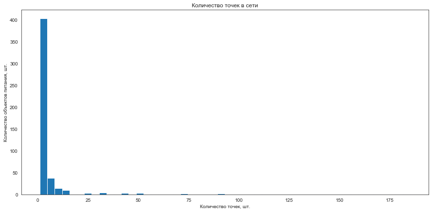

```python
chain_rest_grouped = chain_rest.groupby('corr_object_name', as_index = False)['id'].count()
chain_rest_grouped.columns = ['corr_object_name', 'amount']
chain_rest_grouped.hist(bins = 50, figsize = (15,7), grid = False)
plt.title('Количество точек в сети')
plt.xlabel('Количество точек, шт.')
plt.ylabel('Количество объектов питания, шт.')
plt.show()
```

```python
corr_chain_rest_grouped = chain_rest_grouped.query('amount > 1')
print('Среднее', corr_chain_rest_grouped['amount'].mean())
print('Медиана', corr_chain_rest_grouped['amount'].median())
display(corr_chain_rest_grouped['amount'].describe())
```

```
Среднее 12.774038461538462
Медиана 3.0
```

```
count    208.000000
mean      12.774038
std       27.890259
min        2.000000
25%        2.000000
50%        3.000000
75%        8.250000
max      185.000000
Name: amount, dtype: float64
```

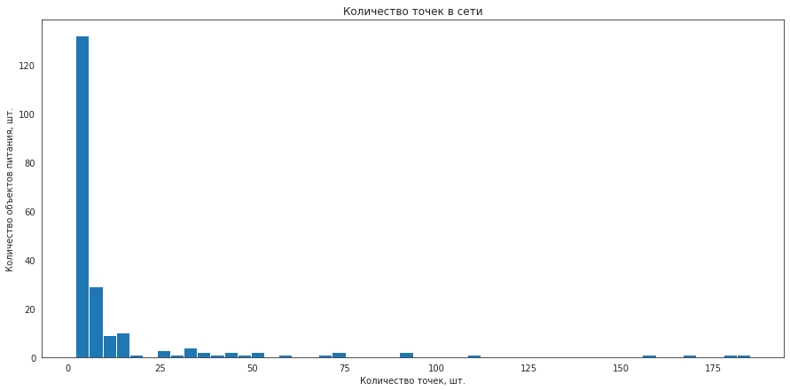

```python
corr_chain_rest_grouped.hist(bins = 50, figsize = (15,7), grid = False)
plt.title('Количество точек в сети')
plt.xlabel('Количество точек, шт.')
plt.ylabel('Количество объектов питания, шт.')
plt.show()
```

```python
report = chain_rest.groupby('corr_object_name', as_index = False).agg({'id':'count', 'number':'mean'})
report.columns = ['corr_object_name', 'amount', 'mean_number']
report = report.query('amount > 1')

report_plot = px.scatter(report, x = 'amount', y = 'mean_number')
# форматируем график
report_plot.update_layout(template = 'plotly_white',
                                    xaxis_title = 'Количество точек, шт.', yaxis_title = 'Количество мест, шт.')
report_plot.show()
```

[interactive chart not shown]

```python
# определяем коэффициент корреляции
corr = report.corr(method = 'pearson')
corr
```

|  | amount | mean_number |
| --- | --- | --- |
| amount | 1.000000 | -0.054918 |
| mean_number | -0.054918 | 1.000000 |

```python
report = chain_rest.groupby('corr_object_name', as_index = False).agg({'id':'count', 'number':'mean'})
report.columns = ['corr_object_name', 'amount', 'mean_number']
report = report.query('amount > 12')

report_plot = px.scatter(report, x = 'amount', y = 'mean_number')
# форматируем график
report_plot.update_layout(template = 'plotly_white',
                                    xaxis_title = 'Количество точек, шт.', yaxis_title = 'Количество мест, шт.')
report_plot.show()
```

[interactive chart not shown]

Определим коэффициент корреляции Пирсона

```python
# определяем коэффициент корреляции
corr = report.corr(method="pearson")
corr
```

|  | amount | mean_number |
| --- | --- | --- |
| amount | 1.000000 | 0.084435 |
| mean_number | 0.084435 | 1.000000 |

Зависимость незначительная: при росте количества точек растет количество мест. При этом если в сети малое количество точек,то разброс по количеству мест значительный.

### Для каждого вида объекта общественного питания найдем среднее количество посадочных мест. Определим, какой вид предоставляет в среднем самое большое количество посадочных мест

```python
rest_data_seats = rest_data.groupby('object_type', as_index = False)['number'].agg({'number':'mean'})
rest_data_seats.sort_values(by = 'number', ascending = False)
```

|  | object_type | number |
| --- | --- | --- |
| 8 | столовая | 130.367767 |
| 7 | ресторан | 97.205026 |
| 1 | буфет | 51.487719 |
| 0 | бар | 43.602579 |
| 3 | кафе | 39.897218 |
| 6 | предприятие быстрого обслуживания | 20.782839 |
| 4 | кафетерий | 9.221374 |
| 2 | закусочная | 7.685879 |
| 5 | магазин (отдел кулинарии) | 5.610294 |

Самое большое количество мест в среднем предоставляет столовая

### Изучим распределение количества посадочных мест для улиц с большим количеством объектов общественного питания. Определим, имеются ли закономерности

Выделим в отдельный столбец информацию об улице из столбца address . Построим график топ-10 улиц по количеству объектов общественного питания. Воспользуемся внешней информацией и ответим на вопрос — в каких районах Москвы находятся эти улицы?

```python
#([-А-яё0-9\s]+)? — группа из любого количества символов из списка: дефис, цифра, буква, пробел; 0 или 1 раз; перед ключевым словом
#(улица|переулок|шоссе|проезд|проспект|площадь|бульвар|тупик|аллея|набережная|квартал) — ключевые слова
#([А-яё0-9\s]+)?  — группа из любого количества символов из списка: цифра, буква, пробел; 0 или 1 раз; после ключевого слова
rest_data['street'] = rest_data['address'].str.extract('(([-А-яё0-9\s]+)?(улица|переулок|шоссе|проезд|проспект|площадь|бульвар|тупик|аллея|набережная|квартал)([А-яё0-9\s]+)?)')[0]
rest_data['street'] = rest_data['street'].str.strip()
```

Для определения района воспользуемся внешней информацией. С [портала открытых данных правительства Москвы](https://data.mos.ru/) скачали два справочника:

- [Общемосковский классификатор территориальных единиц Москвы (ОМК 002-2013)](https://data.mos.ru/classifier/7710168515-obshchemoskovskiy-klassifikator-territorialnyh-edinits-moskvy-omk-002-2013-razdel-1)
- [Общемосковский классификатор улиц Москвы (ОМК 001-2013)](https://data.mos.ru/classifier/7710168515-obshchemoskovskiy-klassifikator-ulits-moskvy-omk-001-2013-razdel-1)

В гугл-документе с помощью функции VLOOKUP объединили эти классификаторы по полю UM_TE (код территориальной единицы). Так как улицы могут быть достаточно протяженными, то неудивительно, что для некоторых улиц в справочнике было указано несколько районов, к которым они относятся. Оставили только первый район из списка.

Теперь для каждого объекта общественного питания можем определить район.

```python
from io import BytesIO
import requests
spreadsheet_id = '1bz13xUiaASi4Kb0BklcUBDG9Os3BCYBEU4Fu6dmju7o'
file_name = 'https://docs.google.com/spreadsheets/d/{}/export?format=csv'.format(spreadsheet_id)
r = requests.get(file_name)
street_classifier = pd.read_csv(BytesIO(r.content))
street_classifier.columns = street_classifier.columns.str.lower()
street_classifier.head()
```

|  | um_code | um_namef | global_id | um_names | um_trans | um_type | um_tm | um_kladr | um_te | um_te_name |
| --- | --- | --- | --- | --- | --- | --- | --- | --- | --- | --- |
| 0 | 008880 | 1-й Ирининский переулок | 58481065 | 1-й Ирининский пер. | Pervy'j Irininskij pereulok | 002 | NaN | 77000000000706300 | 0102 | Басманный район |
| 1 | 008890 | 2-й Ирининский переулок | 58481066 | 2-й Ирининский пер. | Vtoroj Irininskij pereulok | 002 | NaN | 77000000000362200 | 0102 | Басманный район |
| 2 | 008891 | 3-й Ирининский переулок | 58481067 | 3-й Ирининский пер. | Tretij Irininskij pereulok | 002 | NaN | 77000000000362300 | 0102 | Басманный район |
| 3 | 008910 | Иркутская улица | 58481068 | Иркутская ул. | Irkutskaya ulicza | 001 | NaN | 77000000000139700 | 0406 | район Гольяново |
| 4 | 008920 | 1-й Иртышский проезд | 58481069 | 1-й Иртышский пр. | Pervy'j Irty'shskij proezd | 003 | NaN | 77000000000331600 | 0406 | район Гольяново |

```python
rest_data_street = (rest_data
                    .groupby('street', as_index = False)['id']
                    .count()
                    .sort_values(by = 'id', ascending = False)
                   )
rest_data_street_top = (rest_data_street[:10]
                        .merge(street_classifier[['um_namef','um_te_name']],
                               left_on = 'street', right_on = 'um_namef')
                       )

rest_data_street_top.drop('um_namef', axis = 1, inplace = True)
rest_data_street_top = rest_data_street_top.rename(columns = {'um_te_name':'district'})
rest_data_street_top
```

|  | street | id | district |
| --- | --- | --- | --- |
| 0 | проспект Мира | 194 | Мещанский район |
| 1 | Профсоюзная улица | 180 | Академический район |
| 2 | Ленинградский проспект | 172 | район Аэропорт |
| 3 | Пресненская набережная | 165 | Пресненский район |
| 4 | Варшавское шоссе | 163 | Донской район |
| 5 | Ленинский проспект | 148 | район Якиманка |
| 6 | проспект Вернадского | 126 | Гагаринский район |
| 7 | Кутузовский проспект | 114 | район Дорогомилово |
| 8 | Каширское шоссе | 109 | район Москворечье-Сабурово |
| 9 | Кировоградская улица | 107 | район Чертаново Северное |

Можем воспользоваться другим источником данных: http://hubofdata.ru/storage/f/2013-10-29T17%3A30%3A56.887Z/moscow-buildings.csv

Это разбивка адресов по районам. К сожалению, формат названия улиц иной, чем в нашем датасете. Поэтому создаем переменную, в котрой сохраним названия улиц так, как они представлены в источнике. Затем посмотрим, в каком районе на каждой из улиц расположено больше всего объектов. Этот район будем считать районом нахождения улицы.

```python
spreadsheet_id = '1xiUtpkcAjrcgRl8LYf6oa1_yl5wHHYXn9ID2xbQxI4Y'
file_name = 'https://docs.google.com/spreadsheets/d/{}/export?format=csv'.format(spreadsheet_id)
r = requests.get(file_name)
address_classifier = pd.read_csv(BytesIO(r.content))
address_classifier.columns = address_classifier.columns.str.lower()

top_street_tmp = ['пр-кт Мира', 'ул Профсоюзная', 'пр-кт Ленинградский', 'ш Варшавское', 'пр-кт Ленинский', 'пр-кт Вернадского',
                 'пр-кт Кутузовский', 'ш Каширское', 'ул Кировоградская']
address_classifier = (address_classifier
                      .query('full_street_name in @top_street_tmp')
                      .groupby(['full_street_name', 'area_name'], as_index = False)['house_id'].count()
                      .sort_values(by = ['full_street_name', 'house_id'], ascending = False)
                      .groupby(['full_street_name'], as_index = False).agg({'area_name':'first'})
                     )
address_classifier
```

|  | full_street_name | area_name |
| --- | --- | --- |
| 0 | пр-кт Вернадского | муниципальный округ Тропарево-Никулино |
| 1 | пр-кт Кутузовский | муниципальный округ Дорогомилово |
| 2 | пр-кт Ленинградский | муниципальный округ Аэропорт |
| 3 | пр-кт Ленинский | муниципальный округ Гагаринский |
| 4 | пр-кт Мира | муниципальный округ Алексеевский |
| 5 | ул Кировоградская | муниципальный округ Чертаново Центральное |
| 6 | ул Профсоюзная | муниципальный округ Коньково |
| 7 | ш Варшавское | муниципальный округ Нагорный |
| 8 | ш Каширское | муниципальный округ Москворечье-Сабурово |

Построим гистограмму с информацией о количестве объектов на топ-10 улицах.

```python
rest_data_street_top_plot = px.bar(rest_data_street_top, x="street", y="id",
                                   title = 'ТОП-10 улиц расположения объектов')
rest_data_street_top_plot.update_layout(template = 'plotly_white',
                          xaxis_title = 'Улица',
                          yaxis_title = 'Количество объектов, шт.')
rest_data_street_top_plot.show()
```

[interactive chart not shown]

9 из 10 улиц, на которых расположено больше всего объектов, крупные магистрали за пределами садового кольца.

```python
top_street = rest_data_street_top['street']
seats_top_street_plot = px.bar((rest_data
                                .query('street in @top_street')
                                .groupby('street', as_index = False)['number'].median()
                                .sort_values(by = 'number', ascending = False)),
                               x="street", y="number", title = 'Посадочные места в объектах на ТОП-10 улиц')

seats_top_street_plot.update_layout(template = 'plotly_white',
                                    xaxis_title = 'Улица',
                                    yaxis_title = 'Количество посадочных мест, шт.')
seats_top_street_plot.show()
```

[interactive chart not shown]

```python
seats_top_street_plot = px.bar((rest_data
                                .query('street in @top_street and object_type == "предприятие быстрого обслуживания"')
                                .groupby('street', as_index = False)['number'].median()
                                .sort_values(by = 'number', ascending = False)),
                               x="street", y="number", title = 'Посадочные места в ПБО на ТОП-10 улиц')
seats_top_street_plot.update_layout(template = 'plotly_white',
                                    xaxis_title = 'Улица',
                                    yaxis_title = 'Количество посадочных мест, шт.')
seats_top_street_plot.show()
```

[interactive chart not shown]

```python
seats_top_street_plot = px.bar((rest_data
                                .query('street in @top_street and object_type == "кафе"')
                                .groupby('street', as_index = False)['number'].median()
                                .sort_values(by = 'number', ascending = False)),
                               x="street", y="number", title = 'Посадочные места в кафе на ТОП-10 улиц')
seats_top_street_plot.update_layout(template = 'plotly_white',
                                    xaxis_title = 'Улица',
                                    yaxis_title = 'Количество посадочных мест, шт.')
seats_top_street_plot.show()
```

[interactive chart not shown]

```python
seats_top_street_plot = px.bar((rest_data
                                .query('street in @top_street and object_type == "ресторан"')
                                .groupby('street', as_index = False)['number'].median()
                                .sort_values(by = 'number', ascending = False)),
                               x="street", y="number", title = 'Посадочные места в ресторанах на ТОП-10 улиц')
seats_top_street_plot.update_layout(template = 'plotly_white',
                                    xaxis_title = 'Улица',
                                    yaxis_title = 'Количество посадочных мест, шт.')
seats_top_street_plot.show()
```

[interactive chart not shown]

Найдем число улиц с одним объектом общественного питания. Воспользуемся внешней информацией и ответим на вопрос — в каких районах Москвы находятся эти улицы?

```python
rest_data_street_one = (rest_data_street[rest_data_street['id'] == 1]
                        .merge(street_classifier[['um_namef','um_te_name']],
                               left_on = 'street', right_on = 'um_namef')
                       )

rest_data_street_one.drop('um_namef', axis = 1, inplace = True)
rest_data_street_one = rest_data_street_one.rename(columns = {'um_te_name':'district'})
rest_data_street_one = rest_data_street_one.groupby('district', as_index = False)['id'].count()
rest_data_street_one.sort_values('id', ascending = False)[:10]
```

|  | district | id |
| --- | --- | --- |
| 23 | Таганский район | 26 |
| 3 | Басманный район | 25 |
| 109 | район Хамовники | 22 |
| 24 | Тверской район | 19 |
| 48 | район Арбат | 18 |
| 20 | Пресненский район | 16 |
| 78 | район Марьина Роща | 16 |
| 14 | Мещанский район | 15 |
| 59 | район Замоскворечье | 14 |
| 41 | поселение Первомайское | 13 |

```python
one_place_street = rest_data_street[rest_data_street['id'] == 1]['street']
seats_one_place_street_plot = px.bar((rest_data
                                .query('street in @one_place_street and object_type == "предприятие быстрого обслуживания"')
                                .groupby('street', as_index = False)['number'].median()
                                .sort_values(by = 'number', ascending = False)),
                               x="street", y="number", title = 'Посадочные места в ПБО')
seats_one_place_street_plot.update_layout(template = 'plotly_white',
                                    xaxis_title = 'Улица',
                                    yaxis_title = 'Количество посадочных мест, шт.')
seats_one_place_street_plot.show()
```

[interactive chart not shown]

```python
one_place_street = rest_data_street[rest_data_street['id'] == 1]['street']
seats_one_place_street_plot = px.bar((rest_data
                                .query('street in @one_place_street and object_type == "кафе"')
                                .groupby('street', as_index = False)['number'].median()
                                .sort_values(by = 'number', ascending = False)),
                               x="street", y="number", title = 'Посадочные места в кафе')
seats_one_place_street_plot.update_layout(template = 'plotly_white',
                                    xaxis_title = 'Улица',
                                    yaxis_title = 'Количество посадочных мест, шт.')
seats_one_place_street_plot.show()
```

[interactive chart not shown]

```python
one_place_street = rest_data_street[rest_data_street['id'] == 1]['street']
seats_one_place_street_plot = px.bar((rest_data
                                .query('street in @one_place_street and object_type == "ресторан"')
                                .groupby('street', as_index = False)['number'].median()
                                .sort_values(by = 'number', ascending = False)),
                               x="street", y="number", title = 'Посадочные места в ресторане')
seats_one_place_street_plot.update_layout(template = 'plotly_white',
                                    xaxis_title = 'Улица',
                                    yaxis_title = 'Количество посадочных мест, шт.')
seats_one_place_street_plot.show()
```

[interactive chart not shown]

Улицы с одним объектом общественного питания чаще встречаются в центральных районах города

# Выводы

## Общие выводы

Тройка лидеров по количеству заведений: кафе, столовая, ресторан. На эти типы приходится ~70% всех объектов. Сетевых объектов в Москве всего 20%. По количеству лидер среду сетевых объектов — "кафе", но по относительному показателю лидируют предприятия быстрого обслуживания (фаст-фуд), кулинарии, рестораны.

Зависимость между количеством точек и количеством мест не выявлена. Самое большое количество посадочных мест в среднем предоставляет столовая

9 из 10 улиц, на которых находится болше всего объектов, крупные магистрали за пределами садового кольца. Они длинее, чем улицы в центре и вероятно от этого мы получили такие данные. Улицы с одним объектом общественного питания чаще встречаются в центральных районах города

**Баг репорт**: в исходных данных есть дубли, обусловленные человеческим фактором.

## Вывод для инвесторов

Исходя из исследования стоит задуматься об открытии предприятия быстрого обслуживания. В начале это может быть одно заведение, затем может стать сетью или франшизой с небольшим количеством точек. Количество мест в заведении будет отличаться для разных районов и типов объектов: например, открывая фаст-фуд на проспекте Вернадского стоит предусмотреть в среднем 40 посадочных мест. В то время как на Профсоюзной улице люди, по всей видимости, покупают еду в окошках и бегут дальше. Открывая ресторан нужно предусмотреть больше посадочных мест, чем при открытии кафе или ПБО.

В центре будет меньше конкуренции, но есть шанс остаться незамеченными, если это не достаточно популярный район. Из центральных районов стоит присмотреться к Таганке, Басманному или Хамовникам.

# Презентация

- [Google Slides](https://docs.google.com/presentation/d/1stGLCcmV7CsQ-7j2VFLKxei6qBTdaJ6oFoY86__7wqY/edit?usp=sharing)
- [PDF](https://drive.google.com/file/d/1y6NUeeDPADksaQOTOO7zORXover8Zi0e/view?usp=sharing)